# Lab 4

Aleah Querns

2/16/2022

# The Setup

```r
library(tidyverse)
library(datasets)
library(viridis)
library(gridExtra)
library(MuMIn)
library(openxlsx)

knitr::opts_knit$set(root.dir = '~/Documents/K-State Year 2/GEOG728/GEOG728_GIT')
```

# The Dataset

```r
df<-readWorkbook(
  xlsxFile = "DATA/UN_MigrantStockByOriginAndDestination_2019.xlsx",
  sheet = 2,
  startRow = 16,
  colNames = TRUE,
  rowNames = FALSE,
  detectDates = FALSE,
  skipEmptyRows = TRUE,
  skipEmptyCols = TRUE,
  rows = NULL,
  cols = NULL,
  check.names = FALSE,
  sep.names = ".",
  namedRegion = NULL,
  na.strings = "NA",
  fillMergedCells = FALSE
)

dfr<- df

colnames(dfr) <- c("Year", "SortOrder", "Major area, region, country or area of destination", "Notes", "Code", "DataTypeA", colnames(df[7:241]))
```

### Q1: We will only work with the data that uses countries as Major area, region, country or area of destination so your first task is to do some creative cleaning of the imported data. To create a dataset with a single column for destination countries and separate columns for origin countries. You should have column names that mean something (e.g. no X2 column names).

All of the codes <900 or not NAs are countries

```r
#Counties use codes <900 OR !=NA

dfr$Code <- as.numeric(dfr$Code)

dfr_filt  <- dfr %>%
  filter(Code <900, na.rm=TRUE)
```

### Q2: Examine the dataframe you just created. Is it tidy? If not, how is it untidy? Assuming the data is untidy now you should make it tidy (give each variable its own column and each observation its own row).

```r
dfr_tidy <- dfr_filt %>% # make the data into long format for Country of Origin
  pivot_longer(cols= Total:Zimbabwe,
               names_to = "CountryorAreaofOrigin",
               values_to= "MigrantN")
```

### Q3: Now start your exploratory data analysis by examining the structure of the dataset you have constructed. Make sure you determine if you have any NA for migration values? What do these NAs mean? (You may want to check out the documentation on the UN website provided above.) Show your structural analysis below and describe what you found in words.

```r
str(dfr_tidy)
```

```
## tibble [381,640 x 8] (S3: tbl_df/tbl/data.frame)
##  $ Year                                              : num [1:381640] 1990 1990 1990 1990 1990 1990 1990 1990 1990 1990 ...
##  $ SortOrder                                         : chr [1:381640] "1990024" "1990024" "1990024" "1990024" ...
##  $ Major area, region, country or area of destination: chr [1:381640] "Burundi" "Burundi" "Burundi" "Burundi" ...
##  $ Notes                                             : chr [1:381640] NA NA NA NA ...
##  $ Code                                              : num [1:381640] 108 108 108 108 108 108 108 108 108 108 ...
##  $ DataTypeA                                         : chr [1:381640] "B R" "B R" "B R" "B R" ...
##  $ CountryorAreaofOrigin                             : chr [1:381640] "Total" "Other.South" "Other.North" "Afghanistan" ...
##  $ MigrantN                                          : chr [1:381640] "333110" "50676" "8943" NA ...
```

```r
colSums(is.na(dfr_tidy))
```

```
##                                               Year
##                                                  0
##                                          SortOrder
##                                                  0
## Major area, region, country or area of destination
##                                                  0
##                                              Notes
##                                             342160
##                                               Code
##                                                  0
##                                          DataTypeA
##                                                  0
##                              CountryorAreaofOrigin
##                                                  0
##                                           MigrantN
##                                             298195
```

Overall: the structure for dfr_tidy shows 38,1640 rows and 8 columns. Observations (rows) are specific to a particular year (numeric), destination country (character), and origin country (character), where the number of migrants going from one origin country to another destination country in one year is reported in MigrantN.

We do have some additional columns (SortOrder–helps sort stuff from the same destination country together, Code–specific to each destination country, and DataTypeA–type of data used to derive estimates)

In this case, we found NAs in the MigrantN and Notes columns.

I couldn’t really find where this is explained, but NAs for MigrantN could mean that there’s a lack of data for that particular origin/destination for that year. Personally, I prefer to leave these in as a placeholder.

We also see NAs in the Notes section, which just means no notes were made there.

Originally, there might’ve been some NAs for Code, but I removed those in step 1.

### Q4: If anything about your dataset seems odd or inappropriate go ahead and do some additional cleaning or transformation now. Describe what you are doing and why.

First: MigrantN is a character, and should be numeric, so let’s change that

Changing this variable to numeric will also turn the “…” entries to NA, which makes sense.

```r
dfr_tidy$MigrantN <- as.numeric(dfr_tidy$MigrantN)
```

Also–the SortOrder, Notes, and Code columns are pretty unimportant (to me) so I’ll remove them

```r
dfr_tidier <-dfr_tidy %>%
  select(-c(SortOrder, Notes, Code, DataTypeA))
```

And some of the column names are annoying, so I’ll change them

```r
colnames(dfr_tidier) <- c("Year", "Destination", "OriginCountry", "MigrantN")
```

Let’s just check to make sure everything lines up

```r
 length(unique(dfr_tidier$Destination))#how many unique destination countries?
```

```
## [1] 232
```

```r
length(unique(dfr_tidier$OriginCountry))#how many unique origin countries?
```

```
## [1] 235
```

```r
length(unique(dfr_tidier$OriginCountry))*length(unique(dfr_tidier$Destination))*length(unique(dfr_tidier$Year)) #Does the number of origin*destination*years equal total obs?
```

```
## [1] 381640
```

Also, lastly, the Origin Countries have periods instead of spaces, so let’s replace those:

```r
dfr_tidiest<- dfr_tidier
 dfr_tidiest$OriginCountry<-gsub(".", " ", dfr_tidiest$OriginCountry, fixed = TRUE)
```

### Q5: Now move on to describing the important values and variation in your dataset. Describe in words what you find.

```r
  dfr_tidiest %>%
    group_by(Destination)%>%
    summarize(sum(is.na(MigrantN))) %>%
  arrange(desc(.))#how many NAs are there by Destination
```

```
## # A tibble: 232 x 2
##    Destination                        `sum(is.na(MigrantN))`
##    <chr>                                               <int>
##  1 Zimbabwe                                             1582
##  2 Zambia                                               1421
##  3 Yemen                                                1540
##  4 Western Sahara                                       1575
##  5 Wallis and Futuna Islands                            1589
##  6 Viet Nam                                             1470
##  7 Venezuela (Bolivarian Republic of)                    833
##  8 Vanuatu                                              1561
##  9 Uzbekistan                                           1554
## 10 Uruguay                                              1505
## # ... with 222 more rows
```

```r
dfr_tidiest %>%
    group_by(OriginCountry)%>%
    summarize(sum(is.na(MigrantN))) %>%
  arrange(desc(.))#how many NAs are there by Destination
```

```
## # A tibble: 235 x 2
##    OriginCountry                      `sum(is.na(MigrantN))`
##    <chr>                                               <int>
##  1 Zimbabwe                                             1268
##  2 Zambia                                               1282
##  3 Yemen                                                1278
##  4 Western Sahara                                       1554
##  5 Wallis and Futuna Islands                            1582
##  6 Viet Nam                                             1156
##  7 Venezuela (Bolivarian Republic of)                   1159
##  8 Vanuatu                                              1463
##  9 Uzbekistan                                           1255
## 10 Uruguay                                              1240
## # ... with 225 more rows
```

I’m not sure I understand this dataset well enough to know whether the NAs are just because of a lack of recorded data or because it’s a zero. All I know is that these were previously the “…” entries.

```r
x<-dfr_tidiest %>%
  group_by(OriginCountry)%>%
  summarize(meanMigrants = mean(MigrantN, na.rm=T)) %>%
  arrange(desc(meanMigrants))

y<-dfr_tidiest %>%
  group_by(OriginCountry)%>%
  summarize(sdMigrants = sd(MigrantN, na.rm=T)) %>%
  arrange(desc(sdMigrants))

x
```

```
## # A tibble: 235 x 2
##    OriginCountry      meanMigrants
##    <chr>                     <dbl>
##  1 Total                   883044.
##  2 Mexico                  142866.
##  3 Russian Federation      107524.
##  4 India                    87429.
##  5 Bangladesh               83809.
##  6 Ukraine                  75462.
##  7 Afghanistan              74183.
##  8 Kazakhstan               63293.
##  9 State of Palestine       54801.
## 10 China                    52633.
## # ... with 225 more rows
```

```r
y
```

```
## # A tibble: 235 x 2
##    OriginCountry      sdMigrants
##    <chr>                   <dbl>
##  1 Total                3037587.
##  2 Mexico               1190900.
##  3 Russian Federation    458067.
##  4 Bangladesh            437340.
##  5 Ukraine               383876.
##  6 Afghanistan           377957.
##  7 India                 350834.
##  8 Kazakhstan            341340.
##  9 Puerto Rico           254004.
## 10 China                 246423.
## # ... with 225 more rows
```

The top three “origin countries” over the years (AKA places with the most migrants leaving) are “Total” (this is just the total count of migrants for all countries–so yes, it would make sense that this is at the top), Mexico, and Russia. These countries (along with the “Total”) also had the greatest variation (standard deviation) in migrants leaving.

```r
a<-dfr_tidiest %>%
  group_by(Destination)%>%
  summarize(meanMigrants = mean(MigrantN, na.rm=T)) %>%
  arrange(desc(meanMigrants))

b<-dfr_tidiest %>%
  group_by(Destination)%>%
  summarize(sdMigrants = sd(MigrantN, na.rm=T)) %>%
  arrange(desc(sdMigrants))

a
```

```
## # A tibble: 232 x 2
##    Destination                meanMigrants
##    <chr>                             <dbl>
##  1 Saudi Arabia                    774429.
##  2 Pakistan                        725627.
##  3 Iran (Islamic Republic of)      593491.
##  4 United States of America        501957.
##  5 Ukraine                         331955.
##  6 Kazakhstan                      318843.
##  7 India                           312951.
##  8 United Arab Emirates            259983.
##  9 Syrian Arab Republic            242306.
## 10 Côte d'Ivoire                   236169.
## # ... with 222 more rows
```

```r
b
```

```
## # A tibble: 232 x 2
##    Destination                sdMigrants
##    <chr>                           <dbl>
##  1 United States of America     3284832.
##  2 Saudi Arabia                 1782253.
##  3 Pakistan                     1341308.
##  4 India                        1134027.
##  5 Ukraine                      1128203.
##  6 Iran (Islamic Republic of)   1084037.
##  7 Russian Federation           1006894.
##  8 United Arab Emirates          976872.
##  9 Kazakhstan                    834895.
## 10 Germany                       822458.
## # ... with 222 more rows
```

The top three destination countries (AKA countries with highest mean number of migrants) over the study years are Saudi Arabia, Pakistan, and Iran.

The destination countries with the greatest variability over the years (highest standard deviation) are the United States (this is not surprising), Saudi Arabia, and Pakistan.

```r
c<-dfr_tidiest %>%
  group_by(Year)%>%
  summarize(meanMigrants = mean(MigrantN, na.rm=T)) %>%
  arrange(desc(meanMigrants))

d<-dfr_tidiest %>%
  group_by(Year)%>%
  summarize(sdMigrants = sd(MigrantN, na.rm=T)) %>%
  arrange(desc(sdMigrants))

c
```

```
## # A tibble: 7 x 2
##    Year meanMigrants
##   <dbl>        <dbl>
## 1  2019       44506.
## 2  2015       40774.
## 3  2010       36547.
## 4  2005       32521.
## 5  2000       29742.
## 6  1995       27895.
## 7  1990       26463.
```

```r
d
```

```
## # A tibble: 7 x 2
##    Year sdMigrants
##   <dbl>      <dbl>
## 1  2019    579972.
## 2  2015    543418.
## 3  2010    501675.
## 4  2005    450243.
## 5  2000    409696.
## 6  1995    357232.
## 7  1990    323019.
```

The year with the greatest number of mean migrants is 2019, which also had the greatest variation overall.

### Q6: Visualize the important data distributions in your dataset and describe.

For vizualization sake, I’ll take out “total”

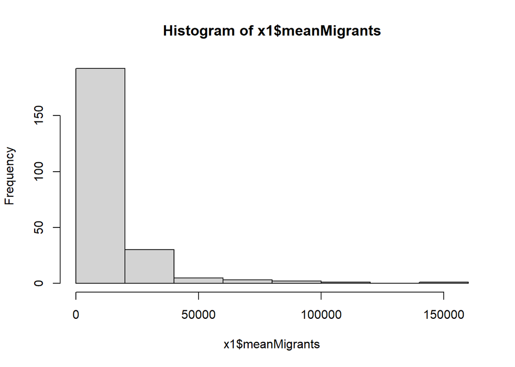

```r
x1<- x %>% filter (OriginCountry!="Total")

hist(x1$meanMigrants, breaks=10) # mean migrants by origin country
```

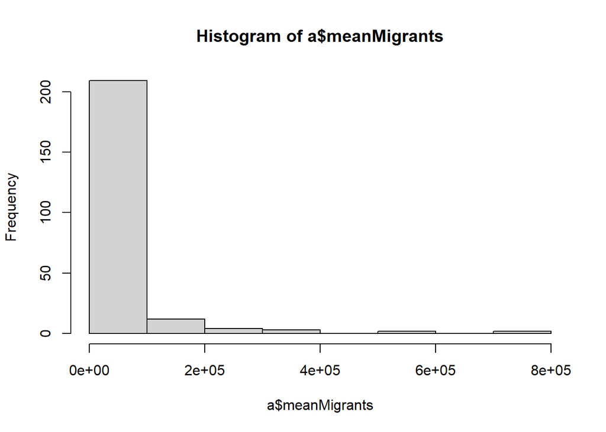

```r
hist(a$meanMigrants, breaks=10) # mean migrants by destination country
```

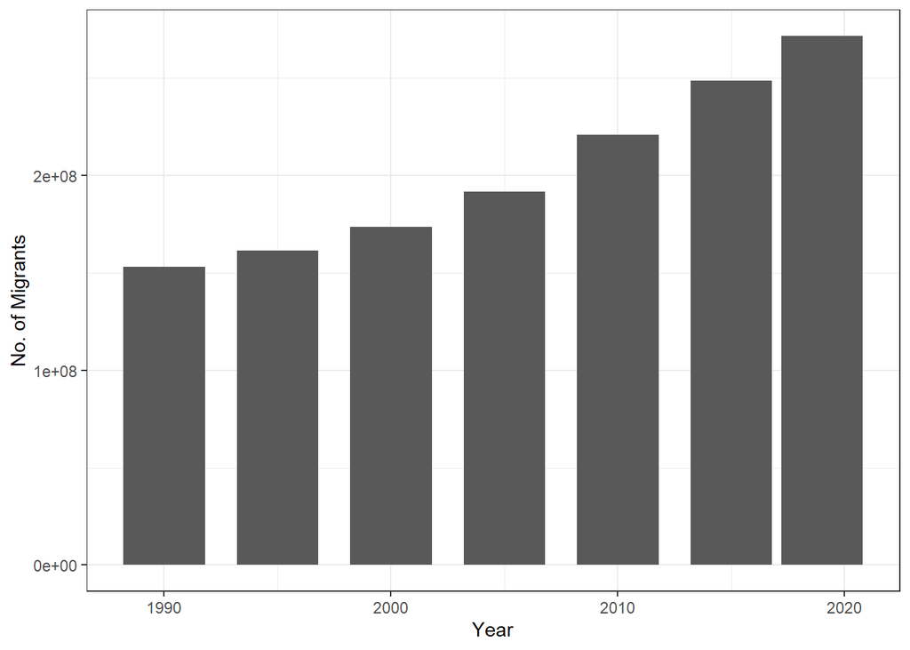

```r
dfr_tidiest%>%
  filter(OriginCountry!= "Total")%>%
ggplot(.)+
  geom_bar(stat = 'identity', aes(x=Year, y=MigrantN))+
  theme_bw()+
  ylab("No. of Migrants")
```

Above, I show:

- a histogram of mean number of migrants across origin countries (did a histogram instead of boxplots because there’s too many countries to look at at once). This distribution has a long tail, meaning that a few countries have many more migrants leaving them.
- a histogram of the mean number of migrants across destination countries (did a histogram instead of boxplots because there’s too many countries to look at at once). This distribution has a long tail, meaning that a few countries have many more migrants entering them.
- Bar plot showing the total number of migrants per year. You can see the number of migrants increases over time (which probably has a lot to do with the world population growing)

### Q7: Explore trends and patterns in your dataset using graphic visualizations and describe what you find.

First, let’s look at worldwide patterns in mean migration numbers.

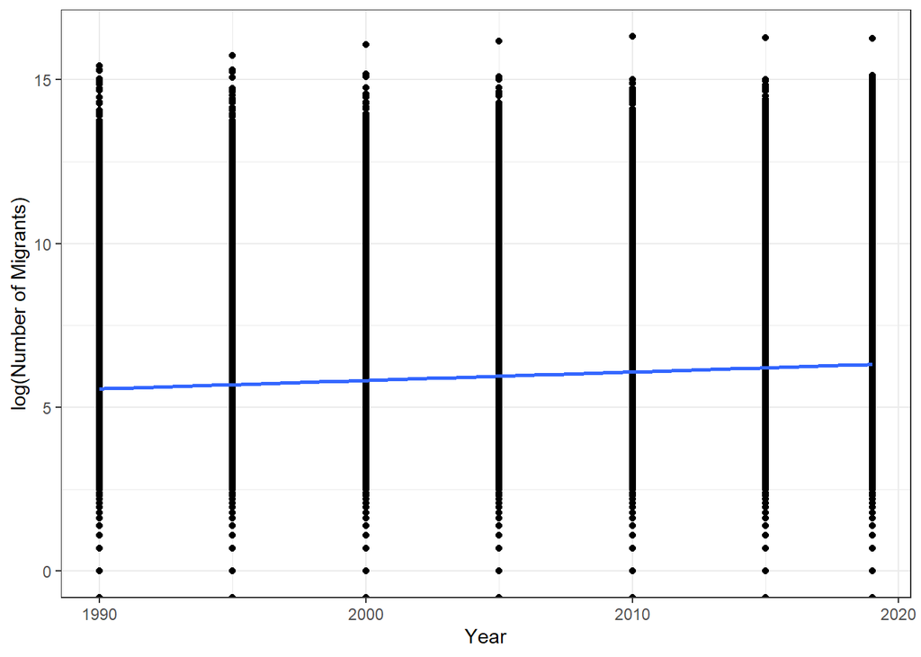

```r
dfr_tidiest %>%
  filter(Destination !="Total"& OriginCountry !="Total")%>%
ggplot(., aes(x=Year, y=log(MigrantN)))+
  geom_point()+
  geom_smooth(method="lm")+
  theme_bw()+
  ylab("log(Number of Migrants)")
```

```r
l1<-lm(MigrantN ~Year, data=dfr_tidiest)
summary(l1)
```

```
##
## Call:
## lm(formula = MigrantN ~ Year, data = dfr_tidiest)
##
## Residuals:
##      Min       1Q   Median       3Q      Max
##   -43011   -37287   -30964   -24661 50618138
##
## Coefficients:
##               Estimate Std. Error t value Pr(>|t|)
## (Intercept) -1233727.0   328672.0  -3.754 0.000174 ***
## Year             632.4      163.9   3.858 0.000115 ***
## ---
## Signif. codes:  0 '***' 0.001 '**' 0.01 '*' 0.05 '.' 0.1 ' ' 1
##
## Residual standard error: 462600 on 83081 degrees of freedom
##   (298557 observations deleted due to missingness)
## Multiple R-squared:  0.0001791,  Adjusted R-squared:  0.0001671
## F-statistic: 14.88 on 1 and 83081 DF,  p-value: 0.0001145
```

*There is a significant increase in numbers of migrants traveling from one country to another over time.*

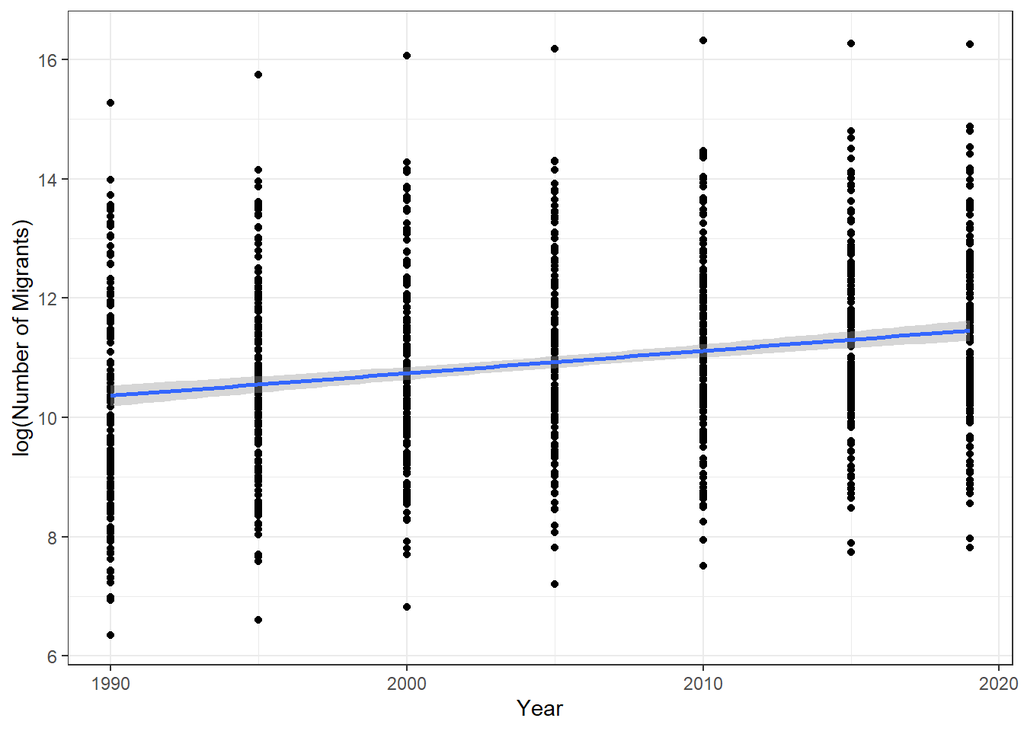

```r
US<-dfr_tidiest %>%
  filter(Destination =="United States of America"& OriginCountry!= "Total" & OriginCountry != "Other South" & OriginCountry != "Other North") %>%
  arrange(desc(OriginCountry))


ggplot(US, aes(x=Year, y=log(MigrantN)))+
  geom_point()+
  geom_smooth(method="lm")+
  theme_bw()+
  ylab("log(Number of Migrants)")
```

```r
l2<-lm(MigrantN ~Year, data=US)
summary(l2)
```

```
##
## Call:
## lm(formula = MigrantN ~ Year, data = US)
##
## Residuals:
##      Min       1Q   Median       3Q      Max
##  -328696  -227318  -160964   -62456 11895021
##
## Coefficients:
##              Estimate Std. Error t value Pr(>|t|)
## (Intercept) -12577883    5419275  -2.321   0.0205 *
## Year             6394       2703   2.365   0.0182 *
## ---
## Signif. codes:  0 '***' 0.001 '**' 0.01 '*' 0.05 '.' 0.1 ' ' 1
##
## Residual standard error: 857500 on 1048 degrees of freedom
##   (574 observations deleted due to missingness)
## Multiple R-squared:  0.005311,   Adjusted R-squared:  0.004361
## F-statistic: 5.595 on 1 and 1048 DF,  p-value: 0.01819
```

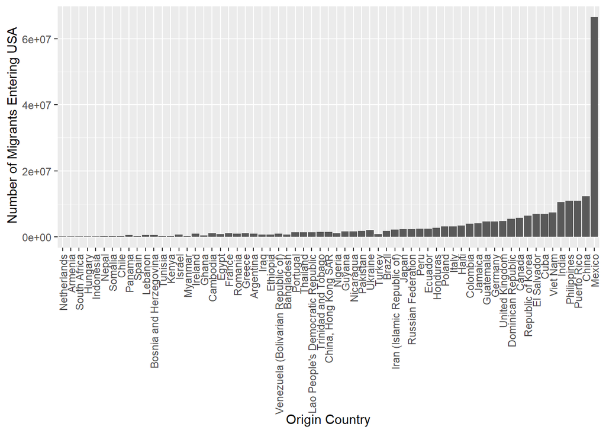

```r
upper<-US %>%
  filter(MigrantN > 100000)

ggplot(upper, aes(x=reorder(OriginCountry, MigrantN), y=MigrantN)) +
         geom_bar(stat = 'identity')+
  theme(axis.text.x = element_text(angle = 90, vjust = 0.5, hjust=1)) +
  xlab ("Origin Country") +
  ylab(" Number of Migrants Entering USA")
```

*There is also a significant increase in migrants to the US over time, which is primarily driven by folks coming over from Mexico, followed by China, Puerto Rico, and the Philippines.*

### Q8: Save your created dataframe to a csv file using the write_csv() function. Save this file in your active R Project.

```r
write.csv(dfr_tidiest, file="DATA/cleaned-UNmigrantN.csv")
```